# Basic Growth Scenario

Cale Basaraba

### Introduction

This is a bare bones run of the metaflu simulator.

#### Parameters

$\beta$ = 0.004 – Contact rate

$\gamma$ = 0.167 – Recovery rate

$\mu$ = 0 – Base mortality rate

$\alpha$ = 0.4 – Disease mortality rate

$\phi$ = 0 – Infectiousness of environmental virions

$\eta$ = 0 – Degradation of environmental virions

$\nu$ = 0 – Update rate of environmental virions

$\sigma$ = 0 – Virion shedding rate

$\omega$ = 0.03 – Inter-patch movement rate

$\rho$ = 0 – Contact non-linearity parameter

$\lambda$ = 0 – External force of infection

$\tau$-crit = 0 – Critical surveillance time

$I$-crit = 0 – Threshold for reporting

$\pi$-report = 0 – Reporting probability

$\pi$-detect = 0 – Detection probability

$t_c$-detect = 1 – Mean time (days) to culling after detection

### Initial Run

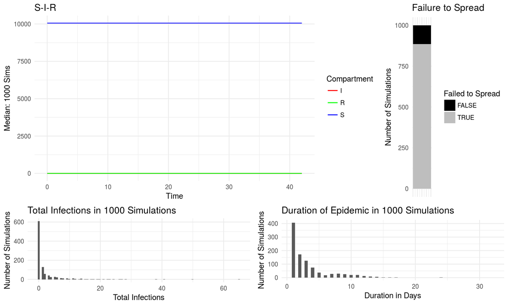

### Growth Run

The only change made to this run is that approximately 11% of the original farms grow to ten-times their original size (~15 to ~150), resulting in twice as many chickens in the entire network. For this experiment, the growing farms are chosen at random.

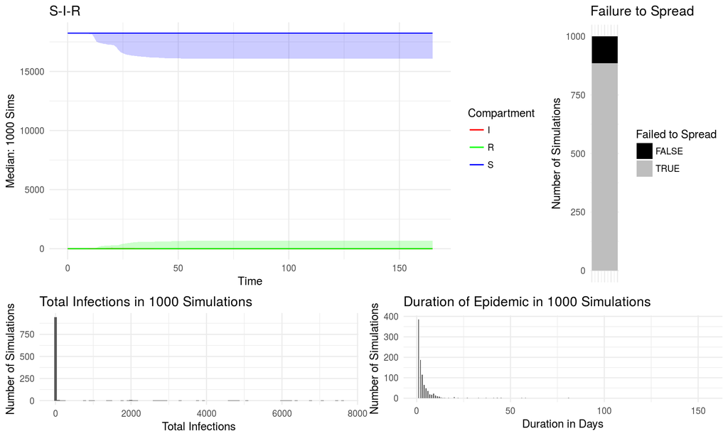